# Analisis Performa Film dan Perilaku Pelanggan pada Database Sakila

Eksplorasi Data Rental DVD Menggunakan R Markdown

Nama: Namira Salva Nur Rizky | NIM: M0725075 | Kelas: C

26 May 2026

**Mata Kuliah:** Sistem Informasi Manajemen  
**Topik:** Analisis Pendapatan dan Pola Rental Film pada Database Sakila

# 1 Pendahuluan

## 1.1 Latar Belakang

Database Sakila merupakan database contoh dari MySQL yang menggambarkan sistem penyewaan DVD film. Database ini memiliki beberapa tabel yang saling berhubungan, seperti data pelanggan, data film, transaksi rental, pembayaran, dan kategori film.

Melalui data tersebut, kita dapat melihat kategori film yang paling sering disewa serta kategori yang memberikan pendapatan terbesar bagi toko rental. Analisis ini dilakukan untuk membantu memahami pola perilaku pelanggan dan melihat hubungan antara jumlah rental dengan total pendapatan yang diperoleh.

Analisis dilakukan menggunakan bahasa pemrograman R dengan bantuan package visualisasi dan statistik agar data lebih mudah dipahami.

## 1.2 Rumusan Masalah

1. Kategori film apa yang menghasilkan pendapatan terbesar?
2. Apakah jumlah rental memiliki hubungan dengan total pendapatan?
3. Bagaimana distribusi rata-rata transaksi pada setiap kelompok kategori film?

# 2 Landasan Teori dan Persamaan Matematis

## 2.1 Simpangan Baku

Simpangan baku digunakan untuk mengukur tingkat penyebaran data terhadap rata-ratanya.

$$s =
\sqrt{\frac{\sum_{i=1}^{n}(x_i-\bar{x})^2}{n-1}}$$

## 2.2 Korelasi Pearson

Korelasi Pearson digunakan untuk mengetahui hubungan linear antara dua variabel.

$$r = \frac{\sum
(x_i-\bar{x})(y_i-\bar{y})}{\sqrt{\sum (x_i-\bar{x})^2 \sum
(y_i-\bar{y})^2}}$$

## 2.3 Uji ANOVA

Uji ANOVA digunakan untuk melihat apakah terdapat perbedaan rata-rata antar kelompok data.

$$F = \frac{MSB}{MSW}$$

# 3 Persiapan Data

## 3.1 Load Library

```r
library(DBI)
library(RMySQL)
library(tidyverse)
library(ggplot2)
library(scales)
library(kableExtra)
library(ggrepel)
library(dplyr)
```

## 3.2 Koneksi Database

```r
con <- dbConnect(
  MySQL(),
  dbname = "sakila",
  host = "localhost",
  port = 3306,
  user = "root",
  password = "password_anda"
)
```

Password database tidak ditampilkan secara langsung untuk menjaga keamanan pengguna.

## 3.3 Data Analisis

```r
df <- data.frame(
  kategori = c(
    "Sports","Sci-Fi","Animation","Drama","Comedy","Action",
    "Family","Documentary","Games","Foreign","New",
    "Children","Classics","Horror","Travel","Music"
  ),

  total_rental = c(
    1179,1101,1166,1060,941,1112,1096,1050,
    969,1033,940,945,939,846,837,830
  ),

  total_pendapatan = c(
    5314,4756,4656,4587,4383,4375,4226,4217,
    4281,4270,4351,3655,3639,3722,3549,3417
  ),

  rata_transaksi = c(
    4.51,4.32,3.99,4.33,4.66,3.93,3.86,4.02,
    4.42,4.13,4.63,3.87,3.88,4.40,4.24,4.12
  ),

  stringsAsFactors = FALSE
)

df <- df %>%
  mutate(
    kelompok = case_when(
      total_pendapatan >= 4500 ~ "Tinggi",
      total_pendapatan >= 4000 ~ "Sedang",
      TRUE ~ "Rendah"
    )
  )
```

# 4 Analisis Deskriptif

## 4.1 Tabel Ringkasan Data

```r
df %>%
  mutate(
    total_pendapatan = dollar(total_pendapatan),
    rata_transaksi = dollar(rata_transaksi),
    total_rental = comma(total_rental)
  ) %>%
  rename(
    "Kategori Film" = kategori,
    "Kelompok" = kelompok,
    "Jumlah Rental" = total_rental,
    "Total Pendapatan" = total_pendapatan,
    "Rata-rata Transaksi" = rata_transaksi
  ) %>%
  kable(
    caption = "Tabel 1. Ringkasan Pendapatan dan Rental Film",
    align = "c"
  ) %>%
  kable_styling(
    bootstrap_options = c("striped","hover","bordered"),
    full_width = TRUE,
    font_size = 13
  ) %>%
  row_spec(0, bold = TRUE, color = "white", background = "#4f6b58")
```

Tabel 1. Ringkasan Pendapatan dan Rental Film

| Kategori Film | Jumlah Rental | Total Pendapatan | Rata-rata Transaksi | Kelompok |
| --- | --- | --- | --- | --- |
| Sports | 1,179 | $5,314 | $4.51 | Tinggi |
| Sci-Fi | 1,101 | $4,756 | $4.32 | Tinggi |
| Animation | 1,166 | $4,656 | $3.99 | Tinggi |
| Drama | 1,060 | $4,587 | $4.33 | Tinggi |
| Comedy | 941 | $4,383 | $4.66 | Sedang |
| Action | 1,112 | $4,375 | $3.93 | Sedang |
| Family | 1,096 | $4,226 | $3.86 | Sedang |
| Documentary | 1,050 | $4,217 | $4.02 | Sedang |
| Games | 969 | $4,281 | $4.42 | Sedang |
| Foreign | 1,033 | $4,270 | $4.13 | Sedang |
| New | 940 | $4,351 | $4.63 | Sedang |
| Children | 945 | $3,655 | $3.87 | Rendah |
| Classics | 939 | $3,639 | $3.88 | Rendah |
| Horror | 846 | $3,722 | $4.40 | Rendah |
| Travel | 837 | $3,549 | $4.24 | Rendah |
| Music | 830 | $3,417 | $4.12 | Rendah |

## 4.2 Statistik Deskriptif

```r
data.frame(
  Statistik = c(
    "Minimum",
    "Maksimum",
    "Rata-rata",
    "Median",
    "Simpangan Baku"
  ),
  Nilai = c(
    min(df$total_pendapatan),
    max(df$total_pendapatan),
    round(mean(df$total_pendapatan),2),
    median(df$total_pendapatan),
    round(sd(df$total_pendapatan),2)
  )
) %>%
  kable(
    caption = "Tabel 2. Statistik Deskriptif Pendapatan",
    align = "c"
  ) %>%
  kable_styling(
    bootstrap_options = c("striped","hover","bordered"),
    full_width = FALSE
  ) %>%
  row_spec(0, bold = TRUE, color = "white", background = "#4f6b58")
```

Tabel 2. Statistik Deskriptif Pendapatan

| Statistik | Nilai |
| --- | --- |
| Minimum | 3417.00 |
| Maksimum | 5314.00 |
| Rata-rata | 4212.38 |
| Median | 4275.50 |
| Simpangan Baku | 508.71 |

Berdasarkan hasil statistik deskriptif, rata-rata pendapatan antar kategori film tidak memiliki perbedaan yang terlalu jauh sehingga distribusi data terlihat cukup stabil.

# 5 Visualisasi Data

## 5.1 Visualisasi 1: Total Pendapatan per Kategori

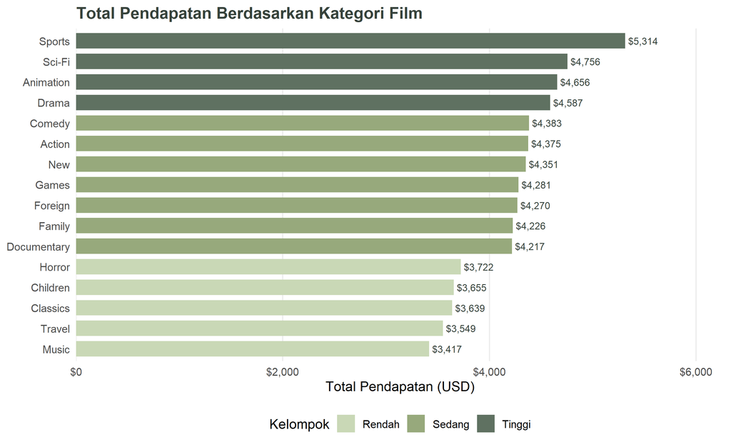

Gambar 1. Total pendapatan berdasarkan kategori film

```r
ggplot(df,
       aes(x=reorder(kategori, total_pendapatan),
           y=total_pendapatan,
           fill=kelompok)) +

  geom_col(width=0.75) +

  geom_text(aes(label=dollar(total_pendapatan)),
            hjust=-0.1,
            size=3,
            color="#36423b") +

  coord_flip() +

  scale_fill_manual(values=c(
    "Tinggi"="#5f7161",
    "Sedang"="#97a97c",
    "Rendah"="#c9d8b6"
  )) +

  scale_y_continuous(
    labels=dollar_format(),
    expand=expansion(mult=c(0,0.18))
  ) +

  labs(
    title="Total Pendapatan Berdasarkan Kategori Film",
    x=NULL,
    y="Total Pendapatan (USD)",
    fill="Kelompok"
  ) +

  theme_minimal(base_size = 12) +

  theme(
    plot.title = element_text(face="bold", color="#36423b"),
    legend.position = "bottom",
    panel.grid.major.y = element_blank(),
    panel.grid.minor = element_blank()
  )
```

## 5.2 Visualisasi 2: Hubungan Rental dan Pendapatan

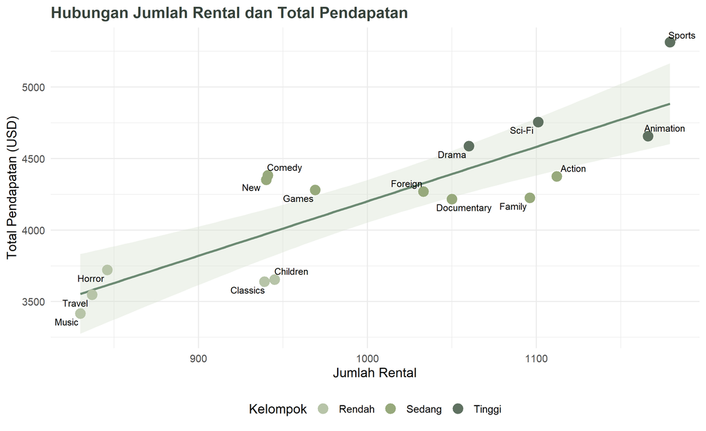

Gambar 2. Hubungan Rental dan Pendapatan

```r
ggplot(df,
       aes(x=total_rental,
           y=total_pendapatan)) +

  geom_smooth(
    method="lm",
    se=TRUE,
    color="#6d8b74",
    fill="#d8e2d0"
  ) +

  geom_point(
    aes(color=kelompok),
    size=4
  ) +

  geom_text_repel(
    aes(label=kategori),
    size=3
  ) +

  scale_color_manual(values=c(
    "Tinggi"="#5f7161",
    "Sedang"="#97a97c",
    "Rendah"="#b7c4a8"
  )) +

  labs(
    title="Hubungan Jumlah Rental dan Total Pendapatan",
    x="Jumlah Rental",
    y="Total Pendapatan (USD)",
    color="Kelompok"
  ) +

  theme_minimal(base_size = 12) +

  theme(
    plot.title = element_text(face="bold", color="#36423b"),
    legend.position = "bottom"
  )
```

## 5.3 Visualisasi 3: Distribusi Rata-rata Transaksi

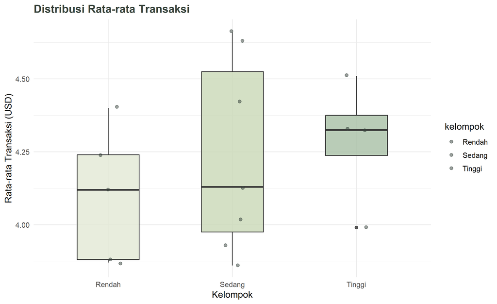

Gambar 3. Distribusi rata-rata transaksi

```r
ggplot(df,
       aes(x=kelompok,
           y=rata_transaksi,
           fill=kelompok)) +

  geom_boxplot(
    alpha=0.8,
    width=0.5,
    show.legend=FALSE
  ) +

  geom_jitter(
    width=0.1,
    alpha=0.5,
    color="#36423b"
  ) +

  scale_fill_manual(values=c(
    "Tinggi"="#a7bfa5",
    "Sedang"="#c9d8b6",
    "Rendah"="#e2e8d5"
  )) +

  labs(
    title="Distribusi Rata-rata Transaksi",
    x="Kelompok",
    y="Rata-rata Transaksi (USD)"
  ) +

  theme_minimal(base_size = 12) +

  theme(
    plot.title = element_text(face="bold", color="#36423b")
  )
```

Berdasarkan boxplot, perbedaan rata-rata transaksi antar kelompok tidak terlalu jauh sehingga pola transaksi terlihat cukup stabil.

# 6 Analisis Inferensial

## 6.1 Uji Korelasi Pearson

```r
cor_test <- cor.test(
  df$total_rental,
  df$total_pendapatan,
  method = "pearson"
)

cor_test
```

```
##
##  Pearson's product-moment correlation
##
## data:  df$total_rental and df$total_pendapatan
## t = 6.0048, df = 14, p-value = 3.228e-05
## alternative hypothesis: true correlation is not equal to 0
## 95 percent confidence interval:
##  0.6093888 0.9463005
## sample estimates:
##       cor
## 0.8487162
```

## 6.2 Uji ANOVA

```r
anova_model <- aov(
  rata_transaksi ~ kelompok,
  data = df
)

summary(anova_model)
```

```
##             Df Sum Sq Mean Sq F value Pr(>F)
## kelompok     2 0.0868 0.04341   0.557  0.586
## Residuals   13 1.0139 0.07799
```

## 6.3 Interpretasi Hasil

Berdasarkan hasil uji korelasi Pearson, diperoleh hubungan positif antara jumlah rental dan total pendapatan. Nilai korelasi yang tinggi menunjukkan bahwa kategori film yang lebih sering disewa cenderung menghasilkan pendapatan yang lebih besar. Selain itu, nilai *p-value* yang lebih kecil dari 0,05 menunjukkan bahwa hubungan tersebut signifikan secara statistik.

Sementara itu, hasil uji ANOVA menunjukkan nilai *p-value* lebih besar dari 0,05. Hal ini berarti tidak terdapat perbedaan rata-rata transaksi yang signifikan antar kelompok kategori film.

**Kesimpulan Analisis:**  
Perbedaan total pendapatan antar kategori film lebih dipengaruhi oleh jumlah rental dibandingkan nilai transaksi per penyewaan. Oleh karena itu, kategori dengan jumlah rental tinggi seperti *Sports*, *Sci-Fi*, dan *Animation* dapat menjadi fokus utama dalam strategi promosi dan pengelolaan stok film.

# 7 Kesimpulan

Berdasarkan hasil analisis yang telah dilakukan, kategori Sports menjadi kategori dengan pendapatan tertinggi sedangkan kategori Music memiliki pendapatan paling rendah.

Selain itu, jumlah rental memiliki hubungan positif terhadap total pendapatan. Semakin tinggi jumlah rental suatu kategori film, maka pendapatan yang diperoleh juga cenderung meningkat.

Secara umum, data pada database Sakila dapat digunakan untuk membantu melihat pola perilaku pelanggan dan menentukan kategori film yang perlu diprioritaskan oleh toko rental.

# 8 Referensi

1. MySQL Documentation. (2026). *Sakila Sample Database*.
2. Wickham, H. (2016). *ggplot2: Elegant Graphics for Data Analysis*. Springer.
3. Wickham, H., & Grolemund, G. (2017). *R for Data Science*. O’Reilly Media.

Laporan dibuat menggunakan R Markdown • Database MySQL Sakila • Sistem Informasi Manajemen